# Lab 6 - Affiliation Networks

Douglas Luke

July 16, 2021

## Introduction

This lab provides an overview of affiliation networks in R. It follows Chapter 9 in the Springer book very closely. The code relies primarily on `igraph` functionality.

```r
library(UserNetR)
library(igraph)
library(xtable)
```

### Affiliations as 2-mode networks

Affiliation networks often arrive as an N by K *incidence matrix*. For example, the following dataframe stores data on students (S) who attend classes (C).

```r
C1 <- c(1,1,1,0,0,0)
C2 <- c(0,1,1,1,0,0)
C3 <- c(0,0,1,1,1,0)
C4 <- c(0,0,0,0,1,1)
aff.df <- data.frame(C1,C2,C3,C4)
row.names(aff.df) <- c("S1","S2","S3","S4","S5","S6")
aff.df
```

```
##    C1 C2 C3 C4
## S1  1  0  0  0
## S2  1  1  0  0
## S3  1  1  1  0
## S4  0  1  1  0
## S5  0  0  1  1
## S6  0  0  0  1
```

### Creating affiliation networks from incidence matrices

Igraph can turn an incidence matrix into a 2-mode affiliation network with one line of code.

```r
bn <- graph.incidence(aff.df)
```

This is what it looks like:

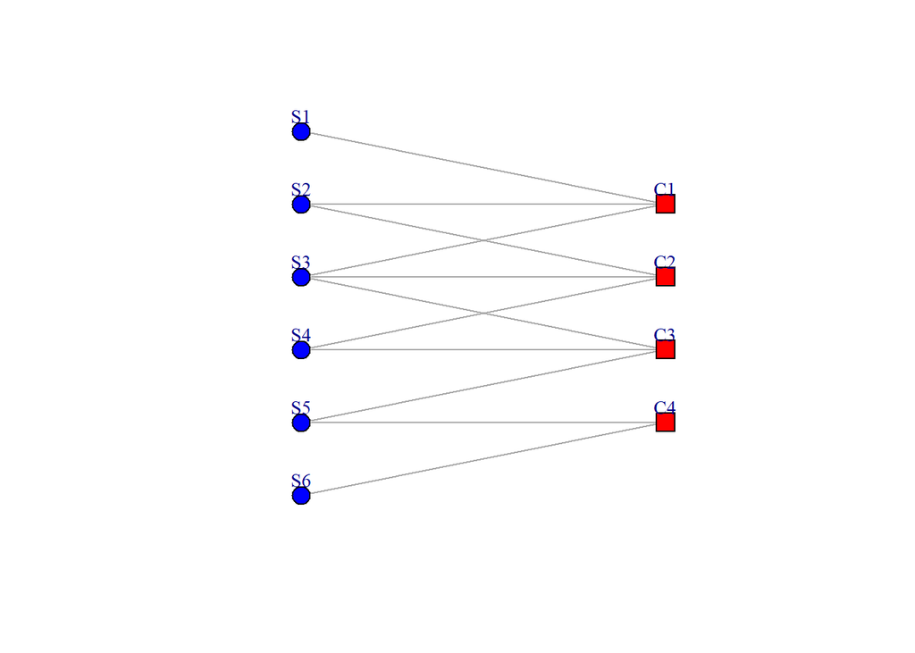

```r
## Plot setup
plt.x <- c(rep(2,6),rep(4,4))
plt.y <- c(7:2,6:3)
lay <- as.matrix(cbind(plt.x,plt.y))

## Affiliation plot example
shapes <- c("circle","square")
colors <- c("blue","red")
plot(bn,vertex.color=colors[V(bn)$type+1],
     vertex.shape=shapes[V(bn)$type+1],
     vertex.size=10,vertex.label.degree=-pi/2,
     vertex.label.dist=1.2,vertex.label.cex=0.9,
     layout=lay)
```

## Affiliation Network Basics

As shown above, an affiliation network is a bipartite graph, where there are two types of nodes and there are ties only between the two types.

The *B* and vertex attribute called *type* are the two clues that igraph provides that tell you this is a bipartite graph. The *type* attribute is what igraph uses to distinguish the two types of nodes.

```r
bn
```

```
## IGRAPH a064015 UN-B 10 11 --
## + attr: type (v/l), name (v/c)
## + edges from a064015 (vertex names):
##  [1] S1--C1 S2--C1 S2--C2 S3--C1 S3--C2 S3--C3 S4--C2 S4--C3 S5--C3 S5--C4
## [11] S6--C4
```

```r
V(bn)$type
```

```
##  [1] FALSE FALSE FALSE FALSE FALSE FALSE  TRUE  TRUE  TRUE  TRUE
```

```r
V(bn)$name
```

```
##  [1] "S1" "S2" "S3" "S4" "S5" "S6" "C1" "C2" "C3" "C4"
```

Notice the correspondence between the node labels and the vertex type in the above output. We can also see the underlying incidence matrix in the 2-mode network using the `get.incidence()` function.

```r
get.incidence(bn)
```

```
##    C1 C2 C3 C4
## S1  1  0  0  0
## S2  1  1  0  0
## S3  1  1  1  0
## S4  0  1  1  0
## S5  0  0  1  1
## S6  0  0  0  1
```

### Creating affiliation networks from edge lists

It is also possible to create affiliation networks from edge lists. This will often be the case for large affiliation networks.

The following example recreates the above network, but starting from edgelist data.

Start by creating a dataframe.

```r
## Affiliation edgelist
el.df <- data.frame(rbind(c("S1","C1"),
             c("S2","C1"),
             c("S2","C2"),
             c("S3","C1"),
             c("S3","C2"),
             c("S3","C3"),
             c("S4","C2"),
             c("S4","C3"),
             c("S5","C3"),
             c("S5","C4"),
             c("S6","C4")))
el.df
```

```
##    X1 X2
## 1  S1 C1
## 2  S2 C1
## 3  S2 C2
## 4  S3 C1
## 5  S3 C2
## 6  S3 C3
## 7  S4 C2
## 8  S4 C3
## 9  S5 C3
## 10 S5 C4
## 11 S6 C4
```

Then, the following two steps are necessary to create the igraph affiliation network. The first step creates a basic network, the second step creates the `type` attribute so that igraph knows it’s a bipartite (affiliation) graph.

```r
bn2 <- graph.data.frame(el.df,directed=FALSE)
bn2
```

```
## IGRAPH a08b6a3 UN-- 10 11 --
## + attr: name (v/c)
## + edges from a08b6a3 (vertex names):
##  [1] S1--C1 S2--C1 S2--C2 S3--C1 S3--C2 S3--C3 S4--C2 S4--C3 S5--C3 S5--C4
## [11] S6--C4
```

```r
V(bn2)$type <- V(bn2)$name %in% el.df[,1]
bn2
```

```
## IGRAPH a08b6a3 UN-B 10 11 --
## + attr: name (v/c), type (v/l)
## + edges from a08b6a3 (vertex names):
##  [1] S1--C1 S2--C1 S2--C2 S3--C1 S3--C2 S3--C3 S4--C2 S4--C3 S5--C3 S5--C4
## [11] S6--C4
```

E: The last piece of code is a little tricky. Can you figure out what is going on?

Q: How can you tell if `bn` and `bn2` are, in fact, the same networks?

### Plotting 2-mode networks

Typically, use shape (and maybe color) to distinguish the two node types.

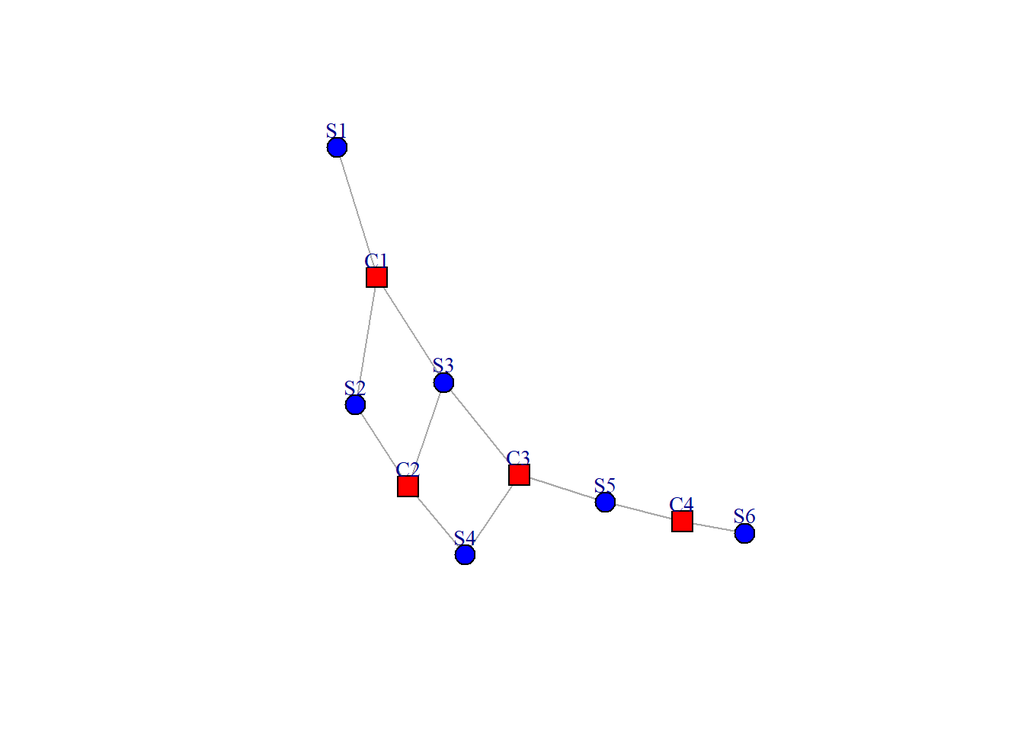

```r
## Simple affiliation plot
shapes <- c("circle","square")
colors <- c("blue","red")
plot(bn,vertex.color=colors[V(bn)$type+1],
     vertex.shape=shapes[V(bn)$type+1],
     vertex.size=10,vertex.label.degree=-pi/2,
     vertex.label.dist=1.2,vertex.label.cex=0.9)
```

### Projections (Creating 1-mode networks from 2-mode networks)

Typically will want to look at one or both of the 1-mode networks that can be derived from the 2-mode network (e.g., the class network or the student network).

Simple to create the projections, but then make sure you know which one is which.

```r
bn.pr <- bipartite.projection(bn)
bn.pr
```

```
## $proj1
## IGRAPH a0a3125 UNW- 6 8 --
## + attr: name (v/c), weight (e/n)
## + edges from a0a3125 (vertex names):
## [1] S1--S2 S1--S3 S2--S3 S2--S4 S3--S4 S3--S5 S4--S5 S5--S6
##
## $proj2
## IGRAPH a0a3125 UNW- 4 4 --
## + attr: name (v/c), weight (e/n)
## + edges from a0a3125 (vertex names):
## [1] C1--C2 C1--C3 C2--C3 C3--C4
```

```r
## Bipartite projections 2
graph.density(bn.pr$proj1)
```

```
## [1] 0.5333333
```

```r
bn.student <- bn.pr$proj1
bn.class <- bn.pr$proj2
graph.density(bn.student)
```

```
## [1] 0.5333333
```

Once you have the projections, then you can explore, analyze, and model each network to you heart’s content!

Look at the underlying data:

```r
get.adjacency(bn.student,sparse=FALSE,attr="weight")
```

```
##    S1 S2 S3 S4 S5 S6
## S1  0  1  1  0  0  0
## S2  1  0  2  1  0  0
## S3  1  2  0  2  1  0
## S4  0  1  2  0  1  0
## S5  0  0  1  1  0  1
## S6  0  0  0  0  1  0
```

```r
get.adjacency(bn.class,sparse=FALSE,attr="weight")
```

```
##    C1 C2 C3 C4
## C1  0  2  1  0
## C2  2  0  2  0
## C3  1  2  0  1
## C4  0  0  1  0
```

Plot them.

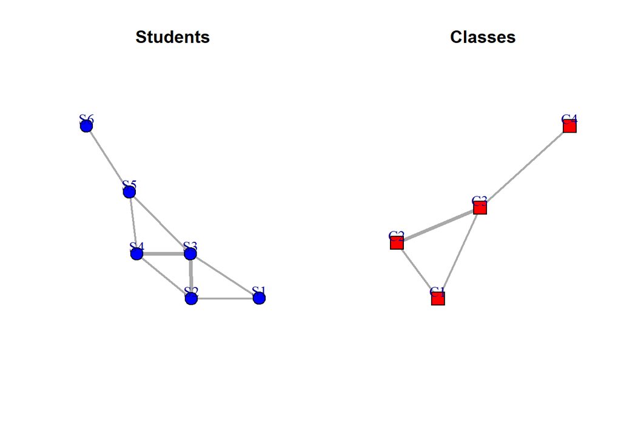

```r
## One-mode projection plots
shapes <- c("circle","square")
colors <- c("blue","red")
op <- par(mfrow=c(1,2))
plot(bn.student,vertex.color="blue",
     vertex.shape="circle",main="Students",
     edge.width=E(bn.student)$weight*2,
     vertex.size=15,vertex.label.degree=-pi/2,
     vertex.label.dist=1.2,vertex.label.cex=1)
plot(bn.class,vertex.color="red",
     vertex.shape="square",main="Classes",
     edge.width=E(bn.student)$weight*2,
     vertex.size=15,vertex.label.degree=-pi/2,
     vertex.label.dist=1.2,vertex.label.cex=1)
```

```r
par(op)
```

## Extended Example: Hollywood Actors as an Affiliation Network

The following sections do not have a lot of commentary, see the Springer book for more explanation.

### 2-mode (actor, movie) affiliation network

Make sure you understand the affiliation network structure of the data.

```r
## Hollywood setup
data(hwd)
h1 <- hwd
h1
```

```
## IGRAPH 9cdab39 UN-B 1365 1600 --
## + attr: name (v/c), type (v/l), year (v/n), IMDBrating (v/n),
## | MPAArating (v/c)
## + edges from 9cdab39 (vertex names):
##  [1] Inception          --Leonardo DiCaprio
##  [2] Inception          --Joseph Gordon-Levitt
##  [3] Inception          --Ellen Page
##  [4] Inception          --Tom Hardy
##  [5] Inception          --Ken Watanabe
##  [6] Inception          --Dileep Rao
##  [7] Inception          --Cillian Murphy
## + ... omitted several edges
```

```r
V(h1)$name[1:10]
```

```
##  [1] "Inception"
##  [2] "Alice in Wonderland"
##  [3] "Kick-Ass"
##  [4] "Toy Story 3"
##  [5] "How to Train Your Dragon"
##  [6] "Despicable Me"
##  [7] "Scott Pilgrim vs. the World"
##  [8] "Hot Tub Time Machine"
##  [9] "Harry Potter and the Deathly Hallows: Part 1"
## [10] "Tangled"
```

```r
V(h1)$type[1:10]
```

```
##  [1] TRUE TRUE TRUE TRUE TRUE TRUE TRUE TRUE TRUE TRUE
```

```r
V(h1)$IMDBrating[1:10]
```

```
##  [1] 8.8 6.5 7.8 8.4 8.2 7.7 7.5 6.5 7.7 7.9
```

```r
V(h1)$name[155:165]
```

```
##  [1] "Notting Hill"               "Eyes Wide Shut"
##  [3] "The Green Mile"             "10 Things I Hate About You"
##  [5] "American Pie"               "Girl, Interrupted"
##  [7] "Leonardo DiCaprio"          "Joseph Gordon-Levitt"
##  [9] "Ellen Page"                 "Tom Hardy"
## [11] "Ken Watanabe"
```

Plotting a small subsection of the network.

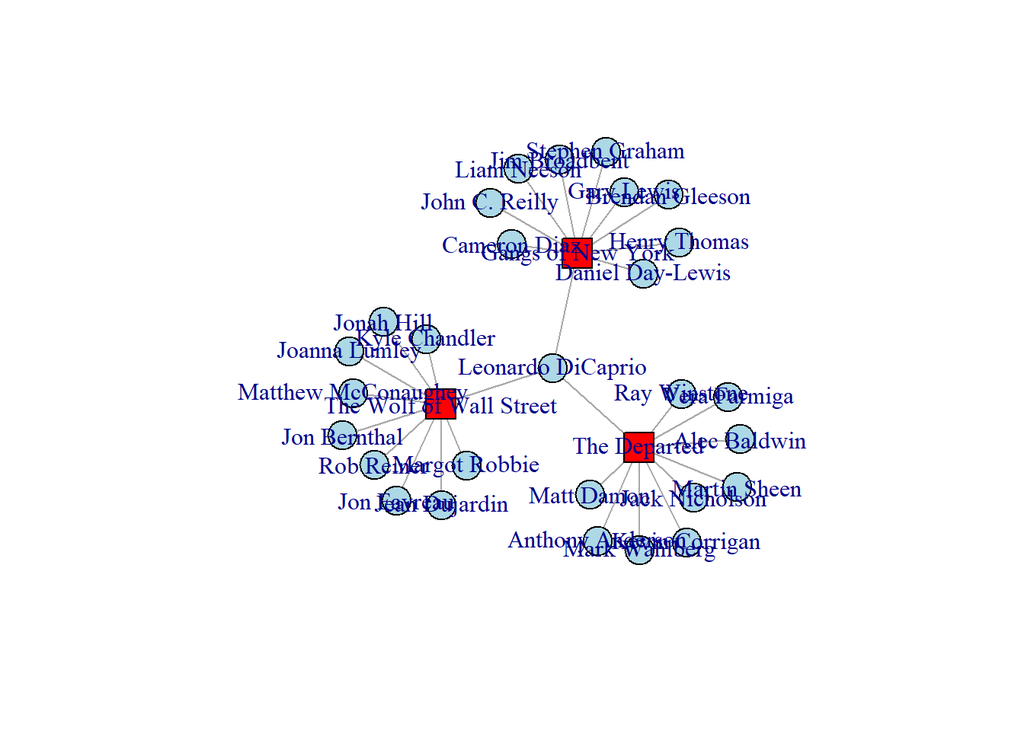

```r
## Hollywood affiliation setup
V(h1)$shape <- ifelse(V(h1)$type==TRUE,
                      "square","circle")
V(h1)$color <- ifelse(V(h1)$type==TRUE,
                      "red","lightblue")

## Hollywood plot
h2 <- subgraph.edges(h1, E(h1)[inc(V(h1)[name %in%
  c("The Wolf of Wall Street","Gangs of New York","The Departed")])])
plot(h2,layout=layout_with_kk)
```

Some exploration of the entire two-mode network.

```r
## Graph density
graph.density(h1)
```

```
## [1] 0.001718711
```

```r
## Hollywood descriptives
table(degree(h1,v=V(h1)[type==FALSE]))
```

```
##
##   1   2   3   4   5   6   7   8
## 955 165  47  23  11   2   1   1
```

```r
mean(degree(h1,v=V(h1)[type==FALSE]))
```

```
## [1] 1.327801
```

Busy actors.

```r
## Hollywood descriptives 2
V(h1)$deg <- degree(h1)
V(h1)[type==FALSE & deg > 4]$name
```

```
##  [1] "Leonardo DiCaprio" "Emma Watson"       "Richard Griffiths"
##  [4] "Harry Melling"     "Daniel Radcliffe"  "Rupert Grint"
##  [7] "James Franco"      "Ian McKellen"      "Martin Freeman"
## [10] "Bradley Cooper"    "Christian Bale"    "Samuel L. Jackson"
## [13] "Natalie Portman"   "Brad Pitt"         "Liam Neeson"
```

```r
busy_actor <- data.frame(cbind(
  Actor = V(h1)[type==FALSE & deg > 4]$name,
  Movies = V(h1)[type==FALSE & deg > 4]$deg
))
busy_actor[order(busy_actor$Movies,decreasing=TRUE),]
```

```
##                Actor Movies
## 5   Daniel Radcliffe      8
## 11    Christian Bale      7
## 1  Leonardo DiCaprio      6
## 2        Emma Watson      6
## 3  Richard Griffiths      5
## 4      Harry Melling      5
## 6       Rupert Grint      5
## 7       James Franco      5
## 8       Ian McKellen      5
## 9     Martin Freeman      5
## 10    Bradley Cooper      5
## 12 Samuel L. Jackson      5
## 13   Natalie Portman      5
## 14         Brad Pitt      5
## 15       Liam Neeson      5
```

Some R code to examine popularity.

```r
## Hollywood descriptives 3
for (i in 161:1365) {
  V(h1)[i]$totrating <- sum(V(h1)[nei(i)]$IMDBrating)
   }

## Hollywood descriptives 4
max(V(h1)$totrating,na.rm=TRUE)
```

```
## [1] 60.9
```

```r
pop_actor <- data.frame(cbind(
  Actor = V(h1)[type==FALSE & totrating > 40]$name,
  Popularity = V(h1)[type==FALSE &
                       totrating > 40]$totrating))
pop_actor[order(pop_actor$Popularity,decreasing=TRUE),]
```

```
##               Actor Popularity
## 3  Daniel Radcliffe       60.9
## 4    Christian Bale       55.5
## 1 Leonardo DiCaprio       49.6
## 2       Emma Watson         45
## 5         Brad Pitt       40.5
```

Are popular actors more active (or vice versa)?

```r
## Hollywood descriptives 5
for (i in 161:1365) {
  V(h1)[i]$avgrating <- mean(V(h1)[nei(i)]$IMDBrating)
   }
num <- V(h1)[type==FALSE]$deg
avgpop <- V(h1)[type==FALSE]$avgrating
summary(lm(avgpop ~ num))
```

```
##
## Call:
## lm(formula = avgpop ~ num)
##
## Residuals:
##     Min      1Q  Median      3Q     Max
## -3.9858 -0.4330  0.1977  0.6170  1.6142
##
## Coefficients:
##             Estimate Std. Error t value Pr(>|t|)
## (Intercept)  7.33868    0.05440 134.911   <2e-16 ***
## num          0.04714    0.03527   1.337    0.182
## ---
## Signif. codes:  0 '***' 0.001 '**' 0.01 '*' 0.05 '.' 0.1 ' ' 1
##
## Residual standard error: 0.9605 on 1203 degrees of freedom
## Multiple R-squared:  0.001483,   Adjusted R-squared:  0.0006528
## F-statistic: 1.786 on 1 and 1203 DF,  p-value: 0.1816
```

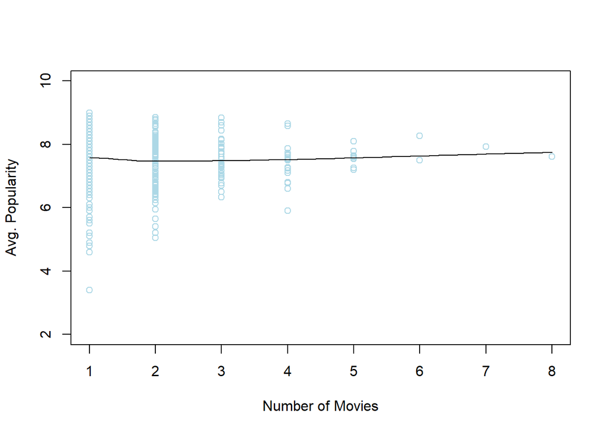

```r
## Hollywood popularity
scatter.smooth(num,avgpop,col="lightblue",
               ylim=c(2,10),span=.8,
               xlab="Number of Movies",
               ylab="Avg. Popularity")
```

### 1-mode neworks

More information can be gleaned from the 1-mode projections of the Hollywood affiliation network.

This produces the actor and movie 1-mode networks.

```r
## Hollywood projections
h1.pr <- bipartite.projection(h1)
h1.act <- h1.pr$proj1
h1.mov <- h1.pr$proj2
h1.act
```

```
## IGRAPH a1da7b4 UNW- 1205 6903 --
## + attr: name (v/c), year (v/n), IMDBrating (v/n), MPAArating (v/c),
## | shape (v/c), color (v/c), deg (v/n), totrating (v/n), avgrating
## | (v/n), weight (e/n)
## + edges from a1da7b4 (vertex names):
##  [1] Leonardo DiCaprio--Joseph Gordon-Levitt
##  [2] Leonardo DiCaprio--Ellen Page
##  [3] Leonardo DiCaprio--Tom Hardy
##  [4] Leonardo DiCaprio--Ken Watanabe
##  [5] Leonardo DiCaprio--Dileep Rao
##  [6] Leonardo DiCaprio--Cillian Murphy
## + ... omitted several edges
```

```r
h1.mov
```

```
## IGRAPH a1da7b4 UNW- 160 472 --
## + attr: name (v/c), year (v/n), IMDBrating (v/n), MPAArating (v/c),
## | shape (v/c), color (v/c), deg (v/n), totrating (v/n), avgrating
## | (v/n), weight (e/n)
## + edges from a1da7b4 (vertex names):
##  [1] Inception--The Wolf of Wall Street    Inception--Django Unchained
##  [3] Inception--The Departed               Inception--Gangs of New York
##  [5] Inception--Catch Me If You Can        Inception--The Dark Knight Rises
##  [7] Inception--10 Things I Hate About You Inception--Batman Begins
##  [9] Inception--The Dark Knight            Inception--Training Day
## [11] Inception--Big Fish
## + ... omitted several edges
```

Some characteristics of the movie network.

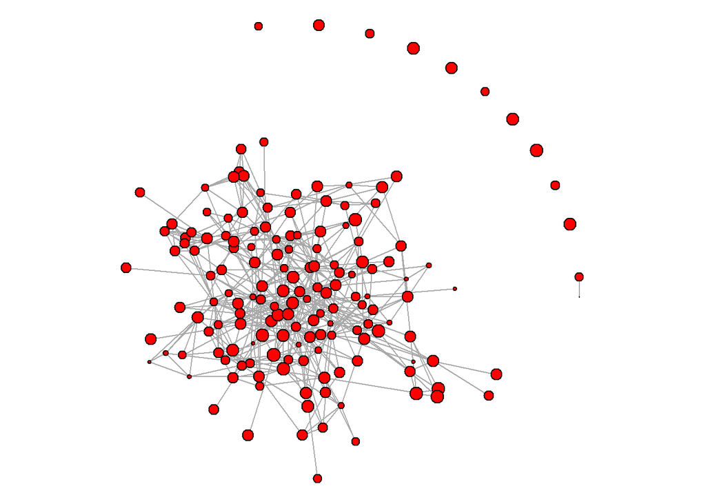

```r
## Movie affiliation network
op <- par(mar = rep(0, 4))
plot(h1.mov,vertex.color="red",
     vertex.shape="circle",
     vertex.size=(V(h1.mov)$IMDBrating)-3,
     vertex.label=NA)
```

```r
par(op)
```

Descriptive statistics.

```r
## Movie descriptives
graph.density(h1.mov)
```

```
## [1] 0.03710692
```

```r
no.clusters(h1.mov)
```

```
## [1] 12
```

```r
clusters(h1.mov)$csize
```

```
##  [1] 148   1   1   1   1   1   1   2   1   1   1   1
```

```r
table(E(h1.mov)$weight)
```

```
##
##   1   2   3   4   5   6   7  10
## 411  21  12  16   6   1   2   3
```

Look at the large connected component of the movie network.

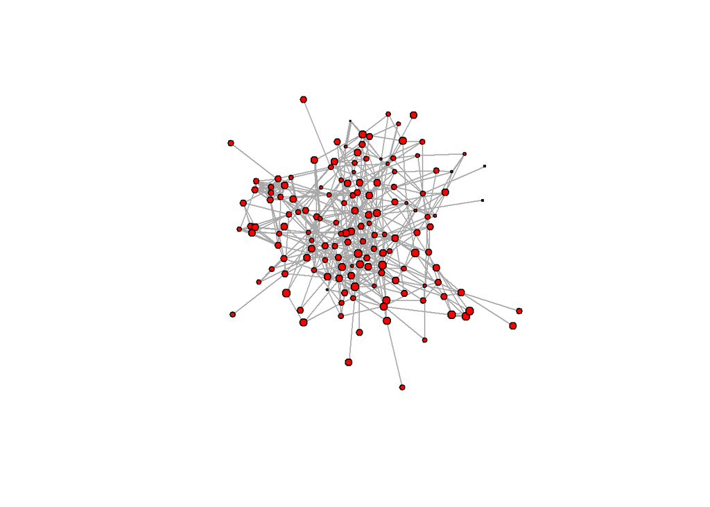

```r
## Movie component
h2.mov <- induced.subgraph(h1.mov,
          vids=clusters(h1.mov)$membership==1)

## Plot movie component
plot(h2.mov,vertex.color="red",
     edge.width=sqrt(E(h1.mov)$weight),
     vertex.shape="circle",
     vertex.size=(V(h2.mov)$IMDBrating)-3,
     vertex.label=NA)
```

Examine the cohesive subgroups based on the k-cores. The figure only includes movies that have coreness greater than 4.

```r
## Hollyword cores distribution
table(graph.coreness(h2.mov))
```

```
##
##  1  2  3  4  5  6  7
## 11  5 23 65 29  7  8
```

```r
## Plot Hollywood cores
h3.mov <- induced.subgraph(h2.mov,
                  vids=graph.coreness(h2.mov)>4)
h3.mov
```

```
## IGRAPH a215f8e UNW- 44 158 --
## + attr: name (v/c), year (v/n), IMDBrating (v/n), MPAArating (v/c),
## | shape (v/c), color (v/c), deg (v/n), totrating (v/n), avgrating
## | (v/n), weight (e/n)
## + edges from a215f8e (vertex names):
## [1] Alice in Wonderland                      --Hot Tub Time Machine
## [2] Hot Tub Time Machine                     --The Interview
## [3] The Hobbit: The Battle of the Five Armies--The Hobbit: The Desolation of Smaug
## [4] Inception                                --The Wolf of Wall Street
## [5] Exodus: Gods and Kings                   --American Hustle
## + ... omitted several edges
```

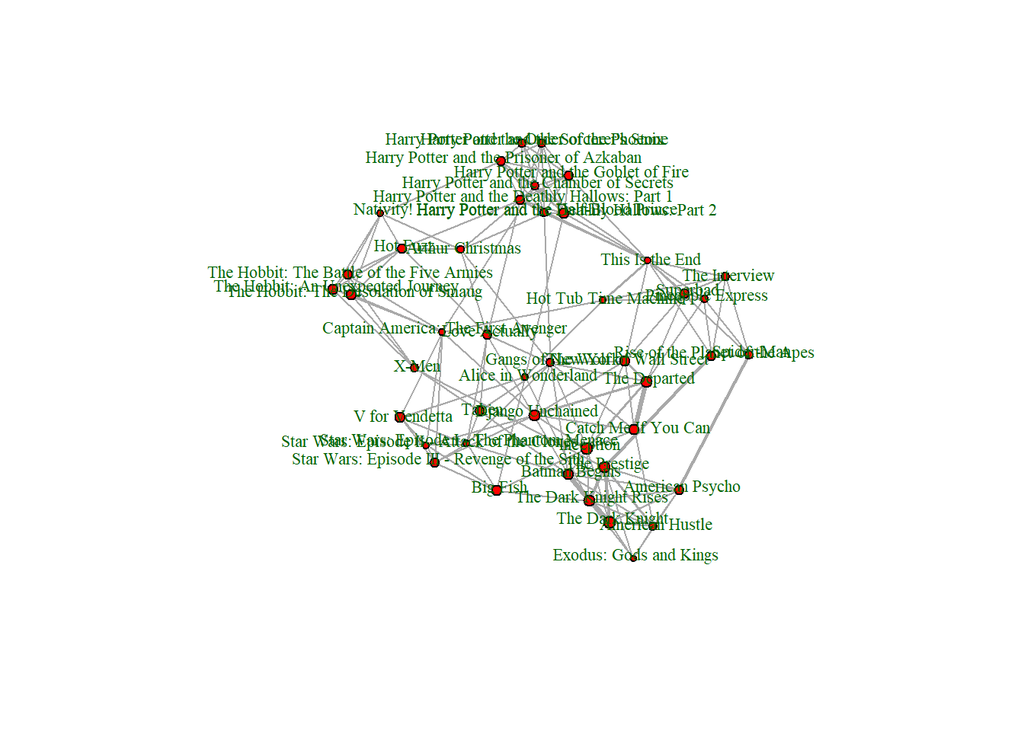

```r
plot(h3.mov,vertex.color="red",
     vertex.shape="circle",
    edge.width=sqrt(E(h1.mov)$weight),
    vertex.label.cex=0.7,vertex.label.color="darkgreen",
    vertex.label.dist=0.3,
     vertex.size=(V(h3.mov)$IMDBrating)-3)
```

E: Conduct some similar exploration of the actor 1-mode network.